# Vigilância de mortalidade no Alto Tâmega e Barroso

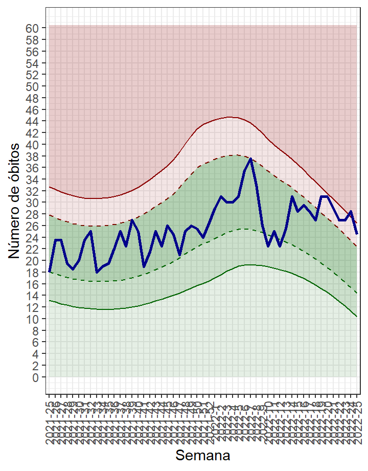

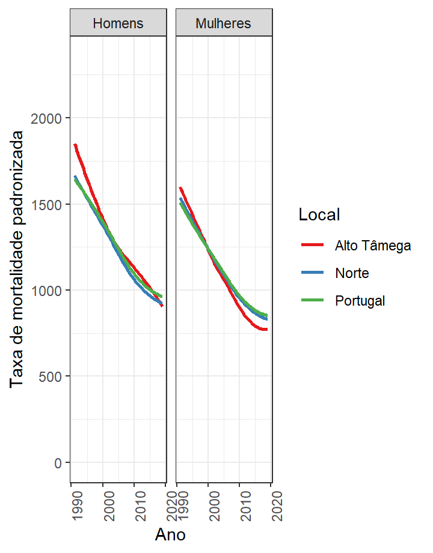

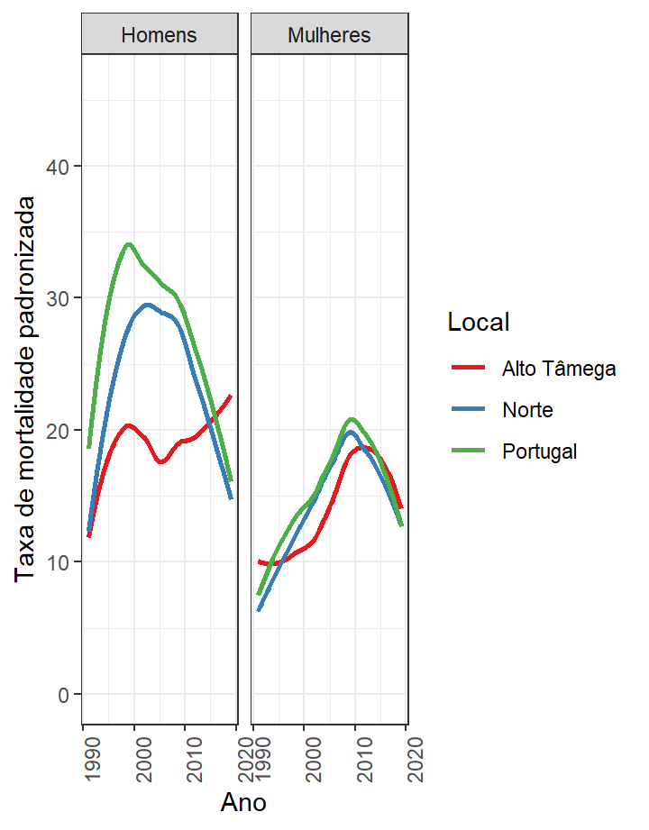

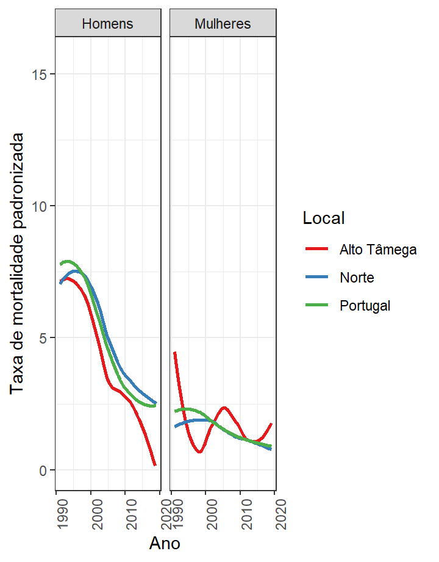

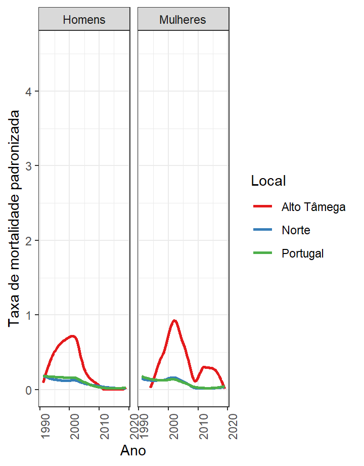

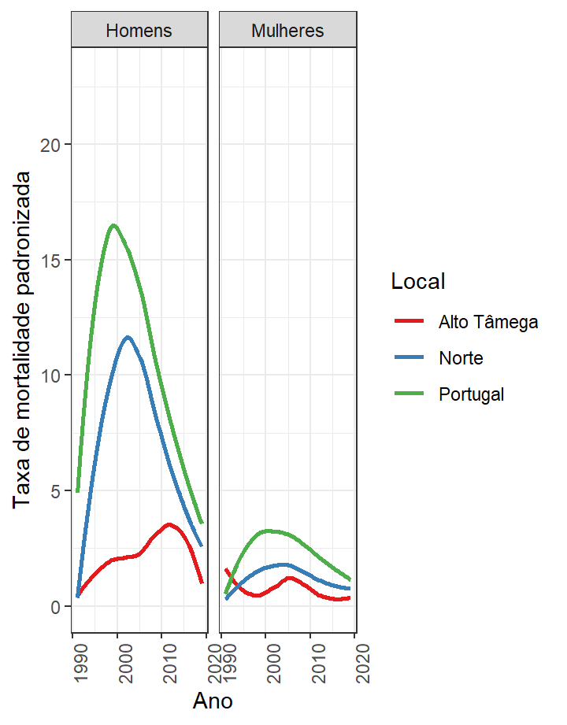

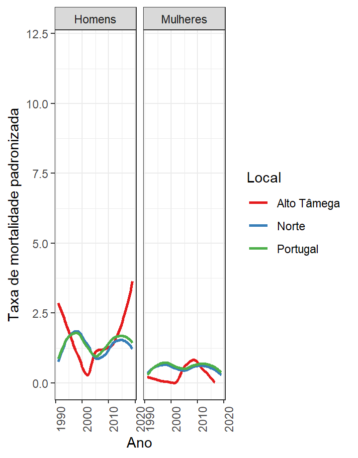

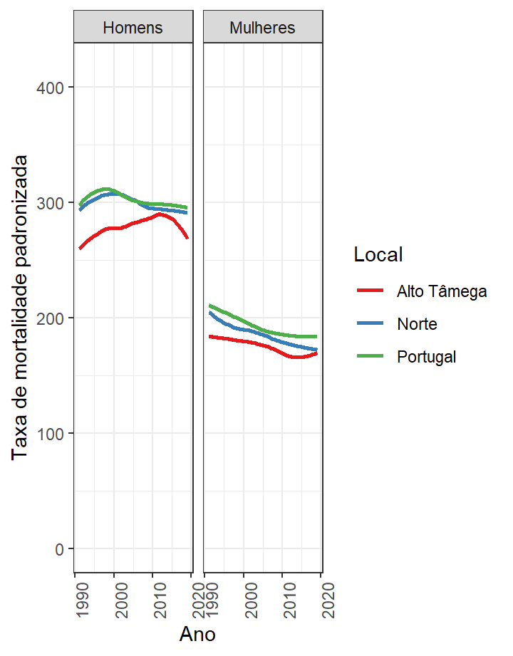

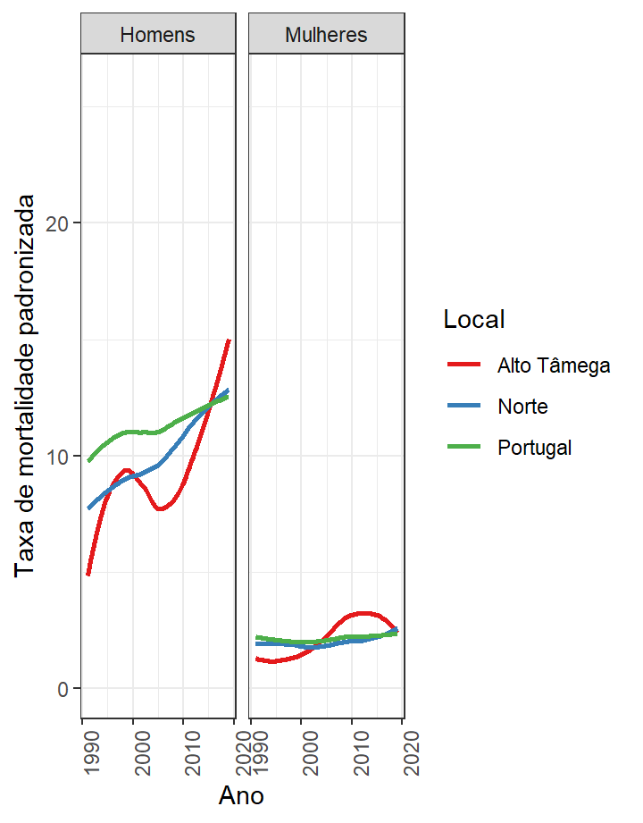

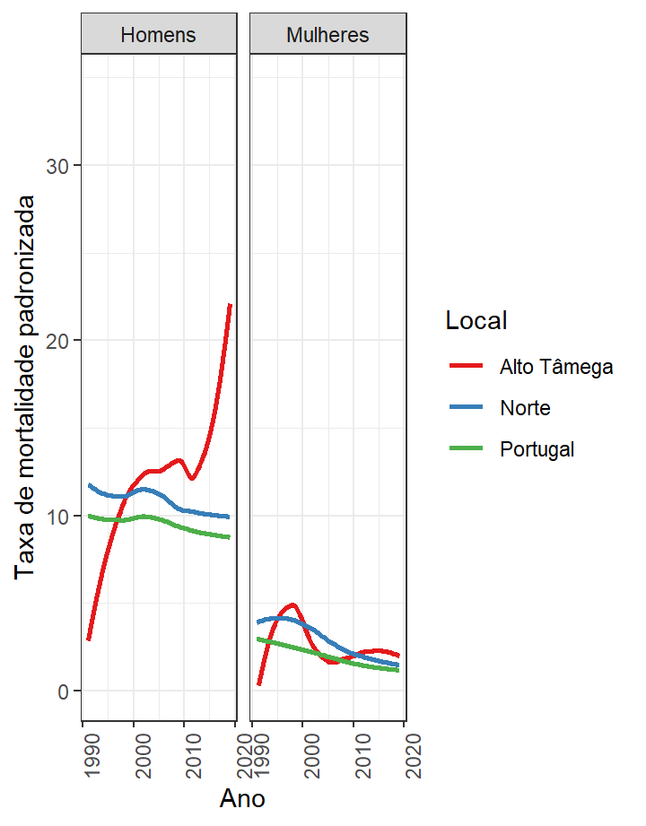

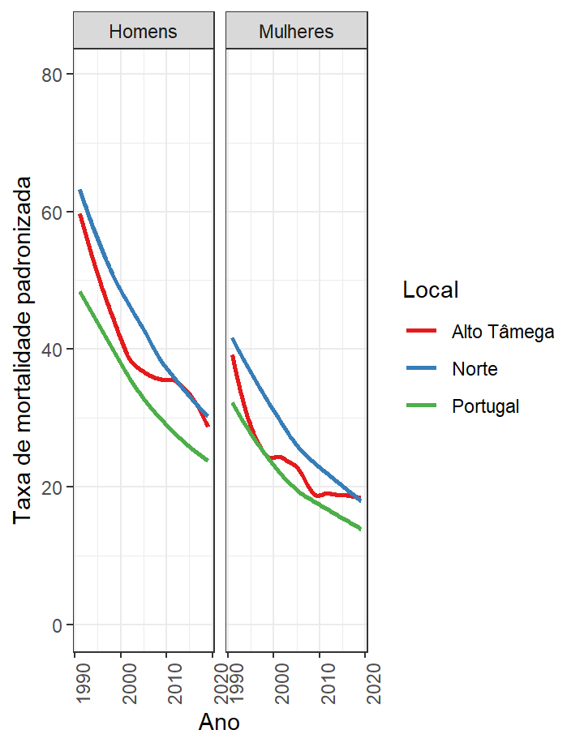

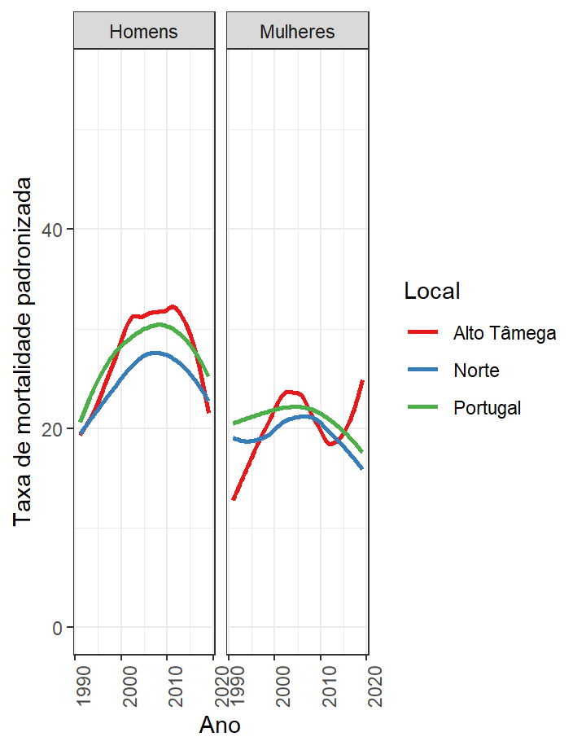

[55 more figures not shown]

# Óbitos

## Coluna 1

### Óbitos verificados

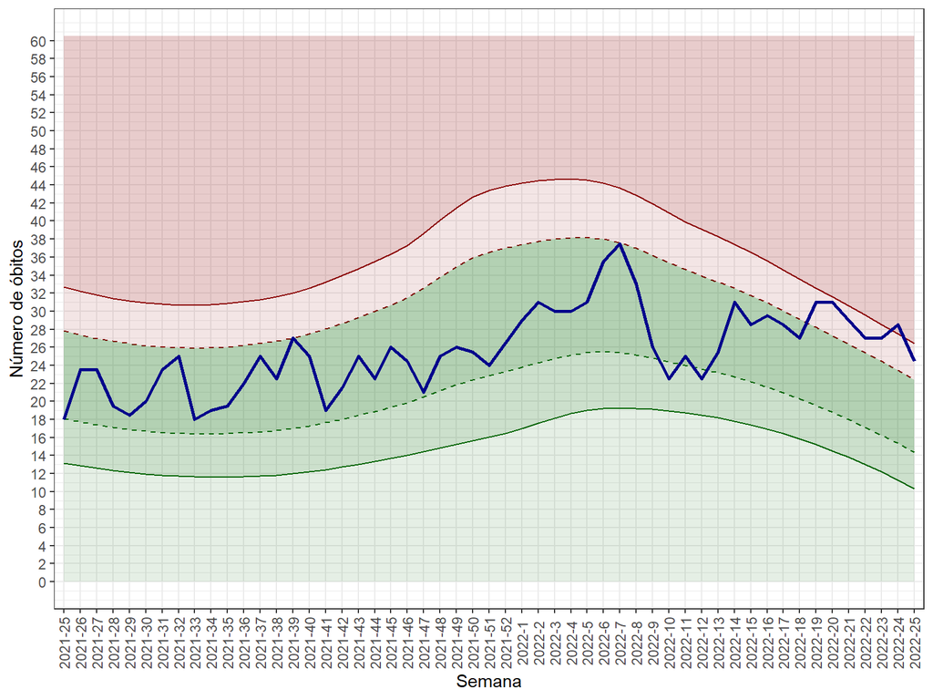

### Explicação e nota metodológica

O gráfico acima apresenta o número de óbitos por todas as causas, na Comunidade Intermunicipal do Alto Tâmega, durante os últimos dozes meses. A linha azul representa o número de óbitos por semana. As linhas verdes e vermelhas representam os valores de referência para cada semana, estimados a partir da média e do desvio padrão dos últimos seis anos (2014–2019).  
O número de óbitos semanal é calculado através do somatório do número de óbitos diários divulgados pelo eVM – Vigilância de Mortalidade, da Direcção-Geral da Saúde. Em cada semana, o número de óbitos indicado representa a média móvel das duas semanas anteriores.

# Todas as causas

## Coluna 1

### Todas as causas

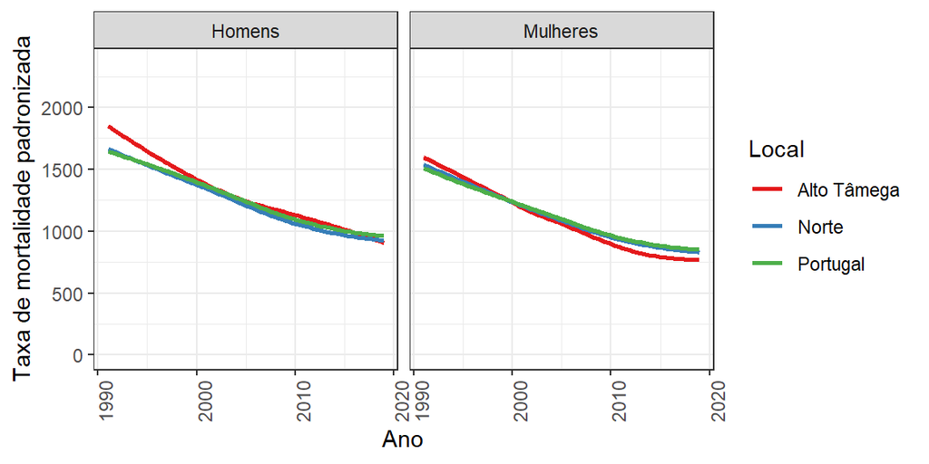

# Doenças infecciosas e parasitárias

## Coluna 1

### Doenças infecciosas e parasitárias

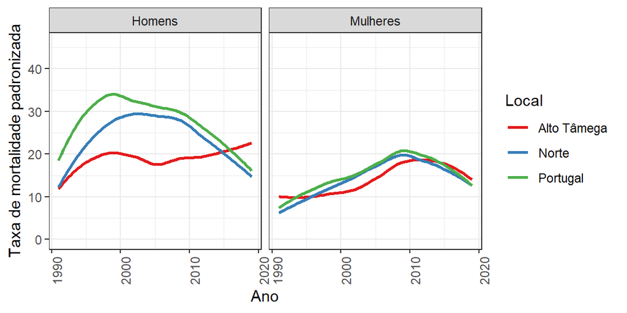

## Coluna 2

### Tuberculose

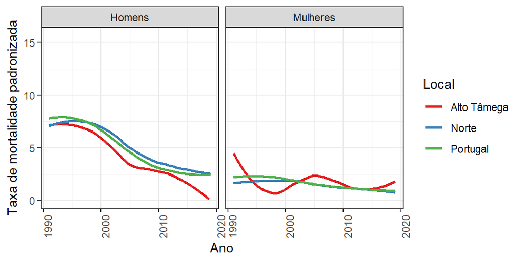

### Infecção meningocócica

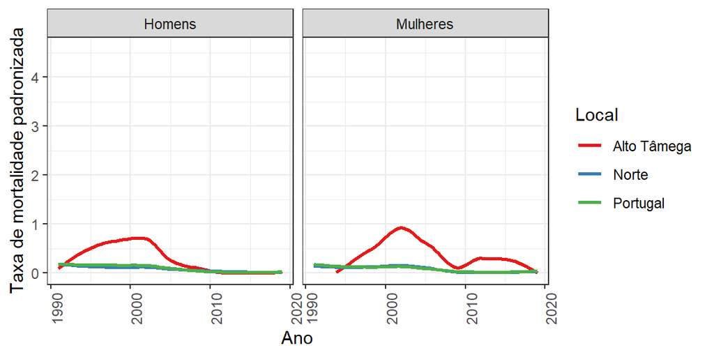

### Vírus da imunodeficiência humana

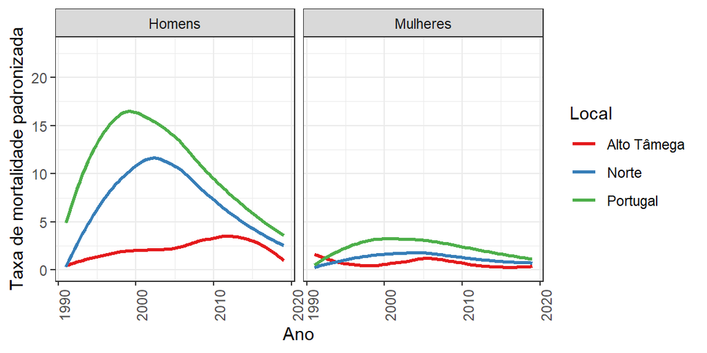

### Hepatite viral

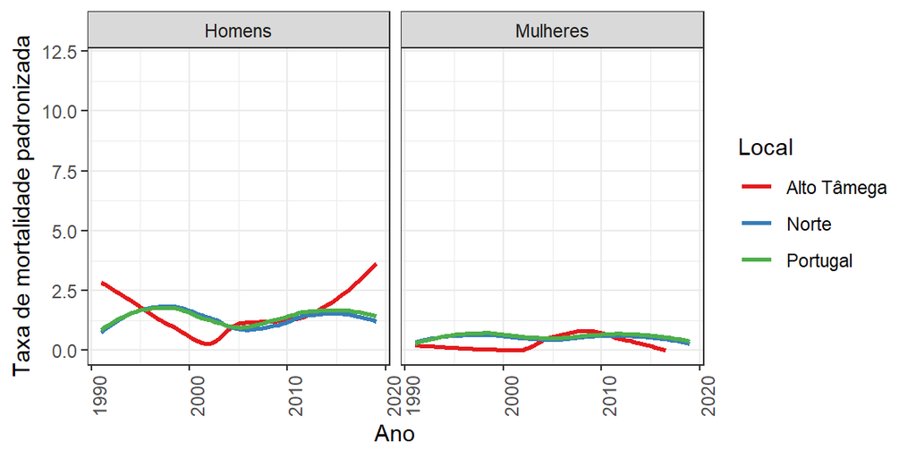

# Neoplasias

## Coluna 1

### Neoplasias malignas

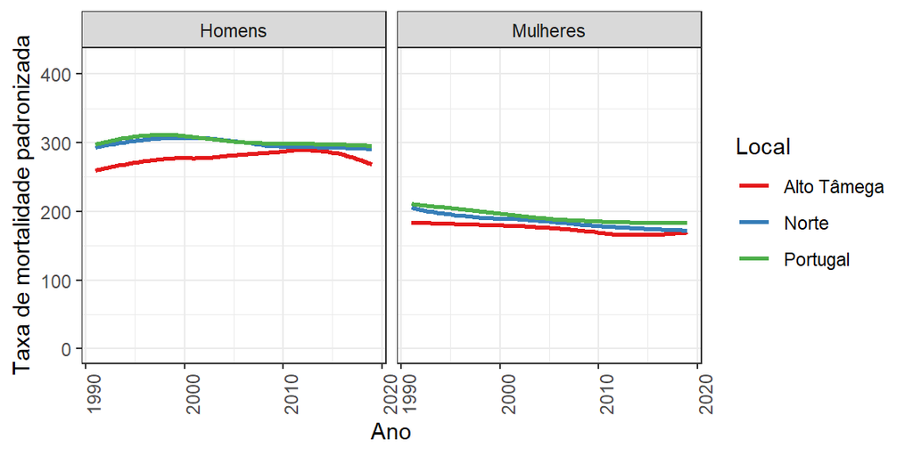

## Coluna 2

### Lábio, cavidade bucal e faringe

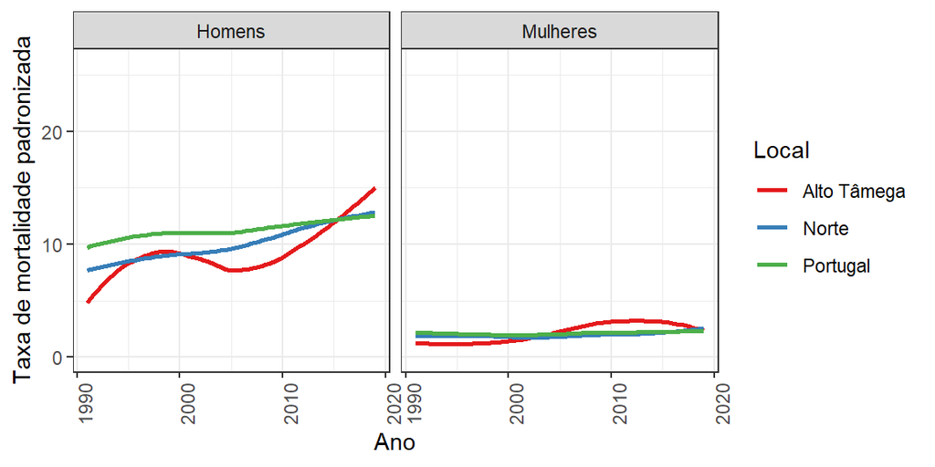

### Esófago

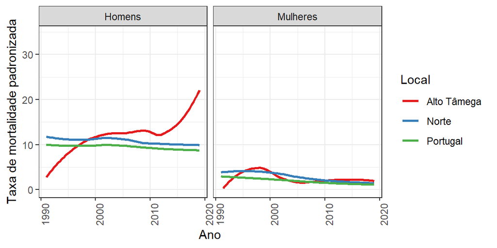

### Estômago

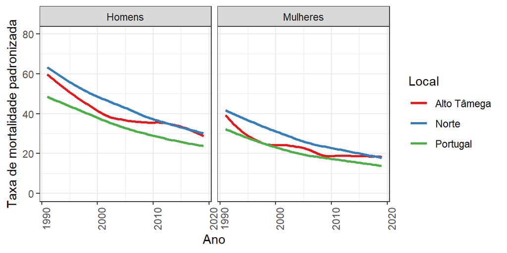

### Cólon

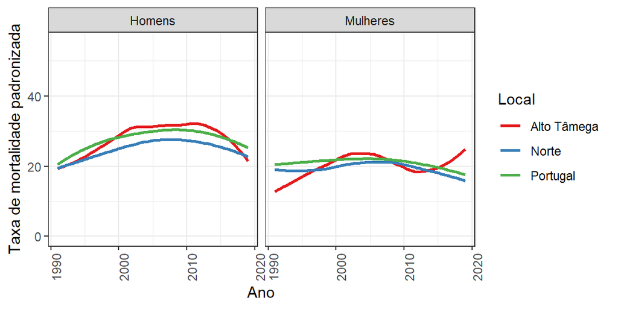

### Junção rectossigmoideia, recto, ânus e canal anal

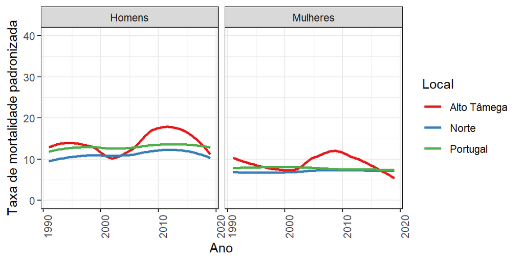

### Fígado e vias biliares intra-hepáticas

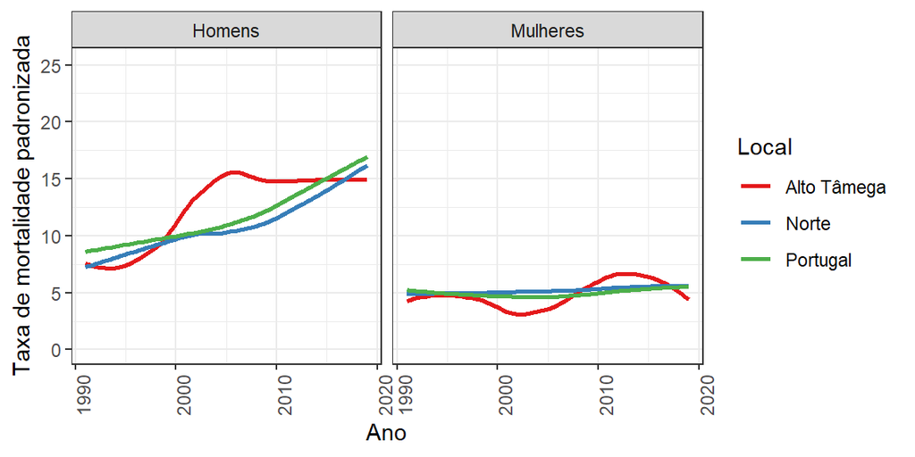

### Pâncreas

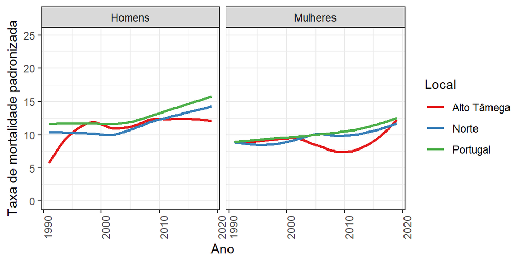

### Laringe, traqueia, brônquios e pulmões

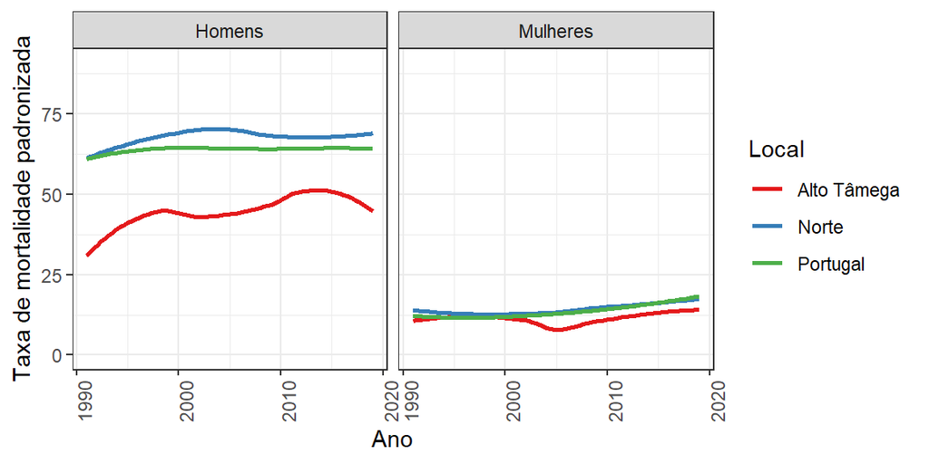

### Melanoma maligno da pele

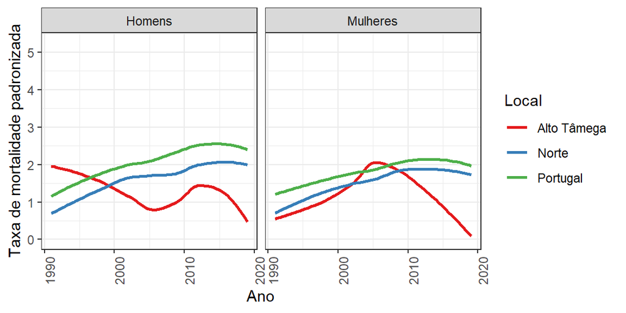

### Mama

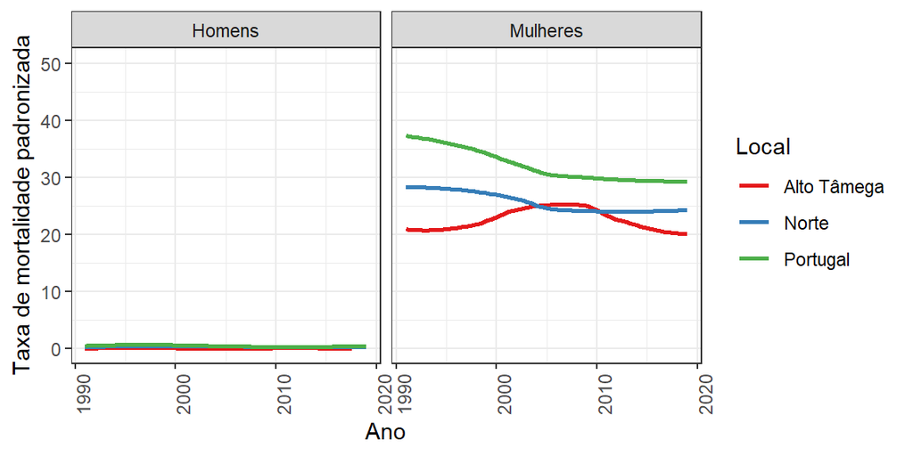

### Colo do útero

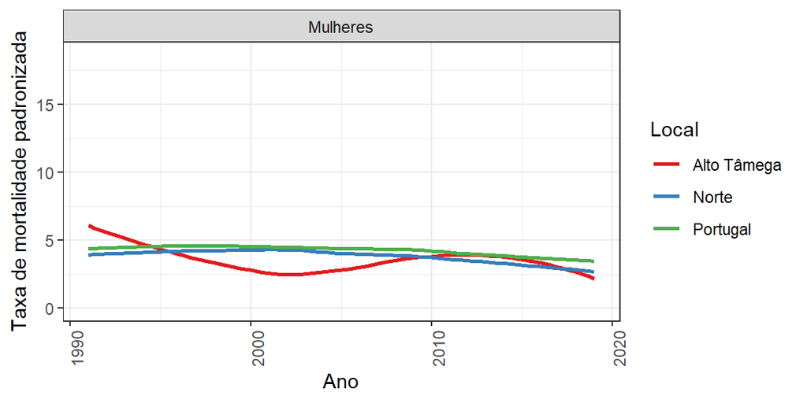